# Toy example of poridge

Phil Reiss & David L Miler

First load up `poridge` and `mgcv`

```r
require(mgcv)
require(poridge)
```

Set the seed…

```r
set.seed(813)
```

Generate some data

```r
Xnl <- matrix(0,30,101)
tt <- sort(sample(1:90,30))
for (i in 1:30) {
  Xnl[i, tt[i]:(tt[i]+4)] <- -1
  Xnl[i, (tt[i]+5):(tt[i]+9)] <- 1
}
X.toy <- Xnl + matrix(rnorm(30*101,,.05),30)

# response
y.toy <- tt + rnorm(30,.05)

# dummy data to go in the s() call
dummy <- 1:30
```

We can plot the data

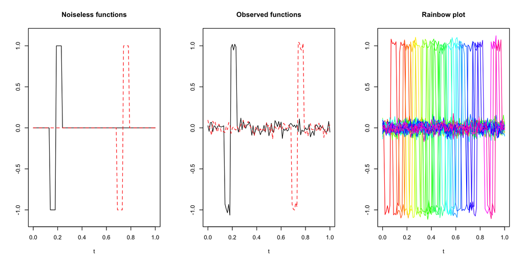

```r
par(mfrow=c(1,3))

matplot((0:100)/100, t(Xnl[c(4,25), ]), type="l", xlab="t", ylab="",
        ylim=range(X.toy), main="Noiseless functions")

matplot((0:100)/100, t(X.toy[c(4,25), ]), type="l", xlab="t", ylab="",
        ylim=range(X.toy), main="Observed functions")

y.rainbow <- rainbow(30, end=0.9)[(y.toy-min(y.toy))/diff(range(y.toy))*29+1]

matplot((0:100)/100, t(X.toy), type="l", lty=1, col=y.rainbow,
        xlab="t", ylab="", main="Rainbow plot")
```

Now calculating the DTW distance

```r
require(dtw)
D <- dist(X.toy, method="dtw", window.type="sakoechiba", window.size=5)
```

Here we fit a series of models with different projection dimensions from 1 to 8 and store the GCV scores. For each projection dimension we fit two models, one using the distances calculated from `dist` in R (`m1`) and one with DTW distance calculated above (`m2`).

```r
GCVmat <- matrix(NA, 8, 2)

for(k. in 1:8){
  m1 <- gam(y.toy ~ s(dummy, bs="pco", k=k., xt=list(realdata=X.toy, dist_fn=dist)), method="REML")
  m2 <- gam(y.toy ~ s(dummy, bs="pco", k=k., xt=list(D=D)), method="REML")

  GCVmat[k., ] <- length(y.toy) * c(sum(m1$residuals^2)/m1$df.residual^2,
                                    sum(m2$residuals^2)/m2$df.residual^2)
}
```

Now plotting the GCV scores

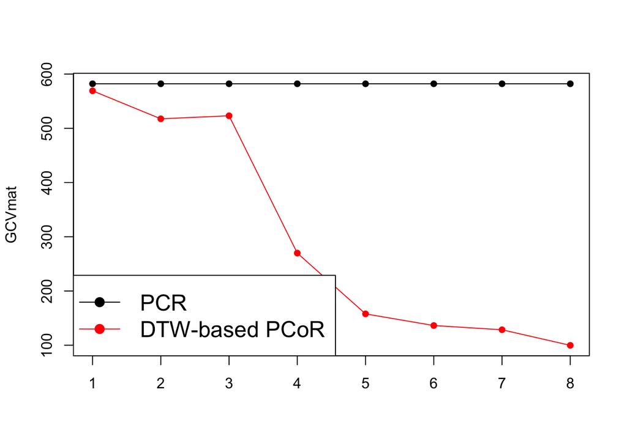

```r
matplot(GCVmat, lty=1, col=1:2, pch=16, type="o")
legend("bottomleft", c("PCR", "DTW-based PCoR"), lty=1, col=1:2, pch=16, cex=1.5)
```

Which was the best DTW model?

```r
which.min(GCVmat[,2])
```

```
## [1] 8
```

```r
m2 <- gam(y.toy ~ s(dummy, bs="pco", k=8, xt=list(D=D)), method="REML")
summary(m2)
```

```
##
## Family: gaussian
## Link function: identity
##
## Formula:
## y.toy ~ s(dummy, bs = "pco", k = 8, xt = list(D = D))
##
## Parametric coefficients:
##             Estimate Std. Error t value Pr(>|t|)
## (Intercept)   45.632      1.538   29.66   <2e-16 ***
## ---
## Signif. codes:  0 '***' 0.001 '**' 0.01 '*' 0.05 '.' 0.1 ' ' 1
##
## Approximate significance of smooth terms:
##         edf Ref.df    F p-value
## dummy 7.646      8 25.1  <2e-16 ***
## ---
## Signif. codes:  0 '***' 0.001 '**' 0.01 '*' 0.05 '.' 0.1 ' ' 1
##
## R-sq.(adj) =  0.874   Deviance explained = 90.7%
## -REML = 117.39  Scale est. = 71.009    n = 30
```

## What if `add=TRUE`

By default we set `add=FALSE` in the MDS step. By setting this to be `TRUE` we add a constant to the distance matrix to ensure that it is Euclidean (see `?cmdscale`). We can now test much higher projection dimensions, since the eigenvalues will be positive.

```r
GCVmat_add <- matrix(NA, 15, 2)

for (k. in 1:15) {
    m1 <- gam(y.toy ~ s(dummy, bs="pco", k=k.,
                        xt=list(realdata=X.toy, dist_fn=dist, add=TRUE)), method="REML")
    m2 <- gam(y.toy ~ s(dummy, bs="pco", k=k., xt=list(D=D, add=TRUE)), method="REML")

    GCVmat_add[k., ] = length(y.toy) * c(sum(m1$residuals^2)/m1$df.residual^2,
                                         sum(m2$residuals^2)/m2$df.residual^2)
}
```

and plotting those results

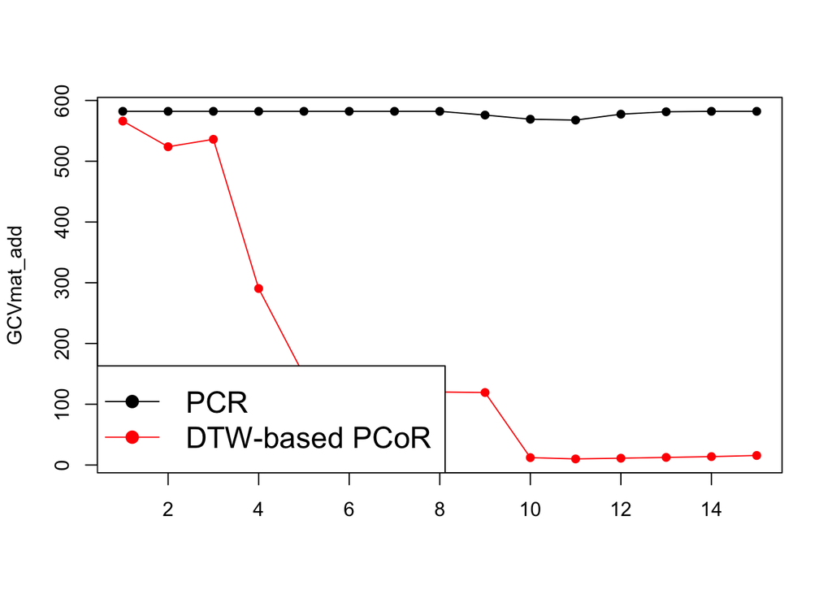

```r
matplot(GCVmat_add, lty=1, col=1:2, pch=16, type="o")
legend("bottomleft", c("PCR", "DTW-based PCoR"), lty=1, col=1:2, pch=16, cex=1.5)
```

```r
m2_add <- gam(y.toy ~ s(dummy, bs="pco", k=which.min(GCVmat_add[,2]), xt=list(D=D, add=TRUE)), method="REML")
summary(m2_add)
```

```
##
## Family: gaussian
## Link function: identity
##
## Formula:
## y.toy ~ s(dummy, bs = "pco", k = which.min(GCVmat_add[, 2]),
##     xt = list(D = D, add = TRUE))
##
## Parametric coefficients:
##             Estimate Std. Error t value Pr(>|t|)
## (Intercept)  45.6320     0.4481   101.8   <2e-16 ***
## ---
## Signif. codes:  0 '***' 0.001 '**' 0.01 '*' 0.05 '.' 0.1 ' ' 1
##
## Approximate significance of smooth terms:
##         edf Ref.df     F p-value
## dummy 10.95     11 243.7  <2e-16 ***
## ---
## Signif. codes:  0 '***' 0.001 '**' 0.01 '*' 0.05 '.' 0.1 ' ' 1
##
## R-sq.(adj) =  0.989   Deviance explained = 99.3%
## -REML = 99.086  Scale est. = 6.0229    n = 30
```

Note we can now fit a model with dimension 11 (minimum by GCV score) rather than 8 (the highest basis dimension possible with `add=FALSE`).